# 624: Exponential Smoothing

# 2 Hyndman: Exercise 8.5

Data set global_economy contains the annual Exports from many countries. Select one country to analyse.

Plot the Exports series and discuss the main features of the data.

*The Exports series for Mexico displays an upward trend beginning during the 1970s. There does not appear to be an indication of a seasonal signal. However, the series may include an irregular multi-year cyclic signal.*

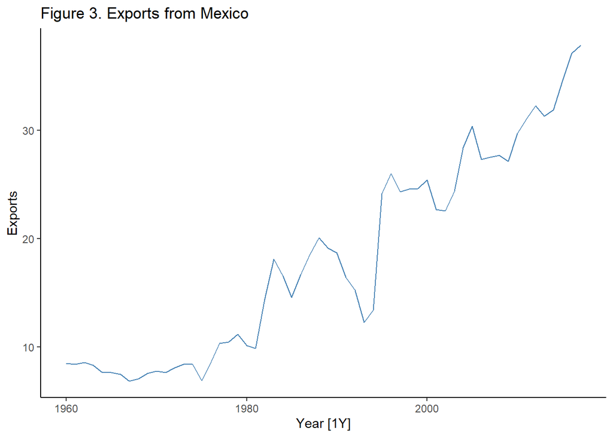

```r
# select Mexico for analysis

Mex<-global_economy%>%
  filter(Country %in% 'Mexico')%>%
  select(Exports)

Mex%>%
  autoplot(Exports, color = 'steelblue')+
  labs(title='Figure 3. Exports from Mexico')+
  theme_classic()
```

Use an ETS(A,N,N) model to forecast the series, and plot the forecasts.

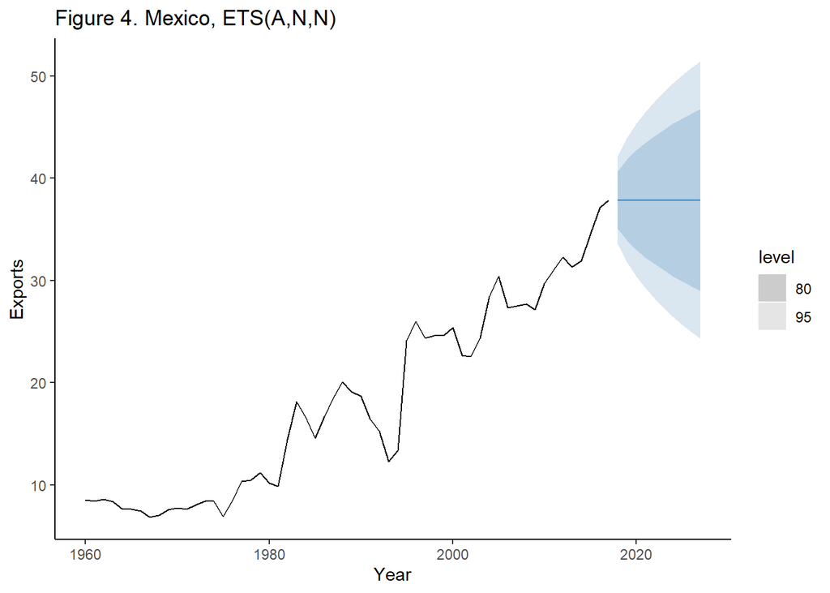

```r
# build model

Mex_mod <- Mex %>%
  model(ETS(Exports ~ error("A") + trend("N") + season("N")))


# forecast 10 years

Mex_fc <- Mex_mod %>%
  forecast(h = 10)

#plot with forecast

Mex_fc %>%
  autoplot(Mex, color='steelblue') +
  labs(title="Figure 4. Mexico, ETS(A,N,N)") +
  theme_classic()
```

Compute the RMSE values for the training data.

*The RMSE for our training set is 2.154. The RMSE is the square root of the mean of the squared differences between actual and predicted data. Or, in other terms, the variance of the residuals*

```r
# compute forecast accuracy measures


RMSE1<-Mex_mod %>% accuracy()
```

Compare the results to those from an ETS(A,A,N) model. (Remember that the trended model is using one more parameter than the simpler model.) Discuss the merits of the two forecasting methods for this data set.

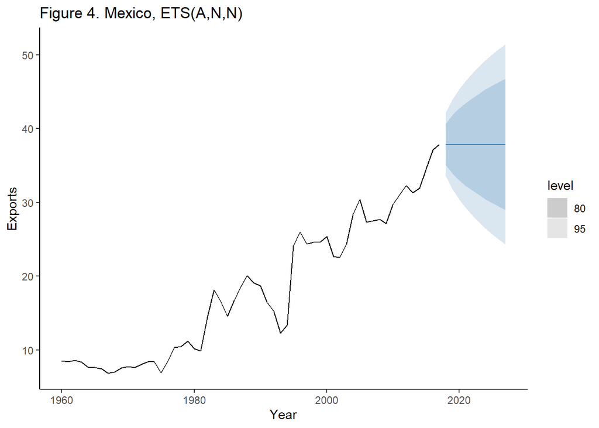

```r
# build model

Mex_AAN_mod <- Mex %>%
  model(ETS(Exports ~ error("A") + trend("A") + season("N")))


# forecast 10 years

Mex_AAN_fc <- Mex_mod %>%
  forecast(h = 10)

#plot with forecast

Mex_AAN_fc %>%
  autoplot(Mex, color='steelblue') +
  labs(title="Figure 4. Mexico, ETS(A,N,N)") +
  theme_classic()
```

```r
# compute forecast accuracy measures


RMSE2<-Mex_AAN_mod %>% accuracy()  # RMSE = 2.093)
```

Compare the forecasts from both methods. Which do you think is best?

*We can use the RMSE measures to compare the accuracy of each model relative to the training set. The ANN model has a higher RMSE (2.154) than the AAN model (2.093), which suggests that the latter provides a better fit to the data.*

```r
# compare RMSE between models

cbind(RMSE1$RMSE, RMSE2$RMSE)%>%
  as.data.frame()%>%
  rename(RMSE_ANN = 'V1', RMSE_AAN = 'V2')%>%flextable()
```

| RMSE_ANN | RMSE_AAN |
| --- | --- |
| 2.154425 | 2.093999 |

Calculate a 95% prediction interval for the first forecast for each model, using the RMSE values and assuming normal errors. Compare your intervals with those produced using R.

```r
# collect first forecast Mex_fc

m1_yhat<-head(Mex_fc$.mean, 1)

# calculate prediction interval manually, sub RMSE for stdev

p1_int<-m1_yhat+1.96*2.154
p2_int<-m1_yhat-1.96*2.154

span1<-p1_int-p2_int



# collect first forecast Mex_AAN_fc


m2_yhat<-head(Mex_AAN_fc$.mean, 1)

# calculate standard deviation

#m2_res<-augment(Mex_AAN_mod)

#m2_stdev<-sd(m2_res$.resid)

# calculate prediction interval manually, sub in RMSE for stdev

p3_int<-m2_yhat+1.96*2.093
p4_int<-m2_yhat-1.96*2.093

span2<- p3_int-p4_int

# compare prediction intervals

pred1<- cbind(p2_int, p1_int, span1)
pred2<- cbind(p4_int, p3_int, span2)


df<-rbind(pred1, pred2)%>%
  as.data.frame()%>%
  rename('Lower 95%' = p1_int, 'Upper 95%' = p2_int, 'Span' = span1)

row.names(df) <- c('ANN', 'AAN')

df
```

|  | Upper 95% | Lower 95% | Span |
| --- | --- | --- | --- |
| ANN | 33.64450 | 42.08818 | 8.44368 |
| AAN | 33.76406 | 41.96862 | 8.20456 |

*The forecast prediction intervals predicted by R (hilo()) are identical compared between ANN and AAN models. However, the span (8.59) is slightly greater than the calculated prediction intervals.*

```r
fc1<-Mex_fc%>%
  hilo()%>%
  as.data.frame()%>%
  select('95%')%>%
  head(1)%>%
  unlist()

fc2<-Mex_AAN_fc%>%
  hilo()%>%
  as.data.frame()%>%
  select('95%')%>%
  head(1)%>%
  unlist()

paste('The span for hilo prediction intervals is', 42.16368-33.56900)
```

```
## [1] "The span for hilo prediction intervals is 8.59468"
```

# 3 Hyndman: Exercise 8.6

Forecast the Chinese GDP from the global_economy data set using an ETS model.

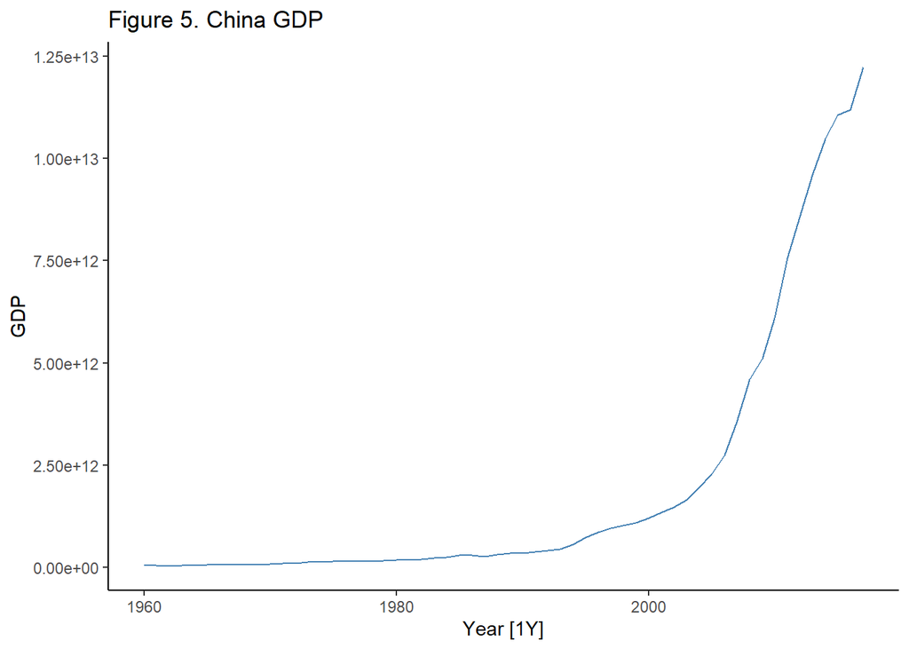

```r
# subset data

gdp<-global_economy%>%
  select(Country, GDP)%>%
  filter(Country %in% 'China')

#Evaluate raw data

gdp%>%autoplot(color='steelblue')+
  labs(title='Figure 5. China GDP')+
  theme_classic()
```

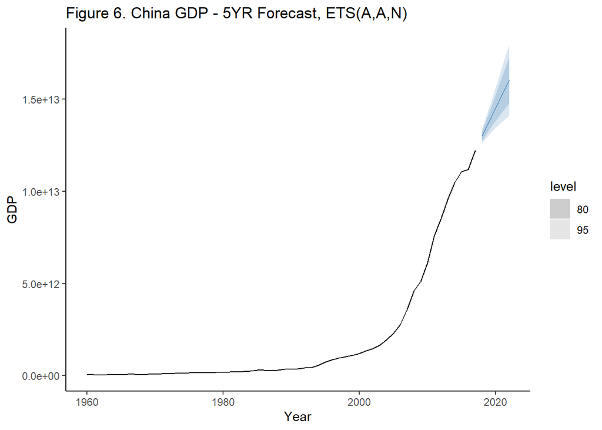

```r
gdp_mod <- gdp %>%
  model(ETS(GDP ~ error("A") + trend("A") + season("N")))

# forecast 5 years

gdp_fc <- gdp_mod %>%
  forecast(h = 5)

#plot with forecast

gdp_fc %>%
  autoplot(gdp, color='steelblue') +
  labs(title="Figure 6. China GDP - 5YR Forecast, ETS(A,A,N)") +
  theme_classic()
```

Experiment with the various options in the ETS() function to see how much the forecasts change with damped trend, or with a Box-Cox transformation. Try to develop an intuition of what each is doing to the forecasts.

The following graph provides a 10 year forecast using the Holts Damped Trend method at two levels of  
$\phi$ (0.8, 0.9). Given that season variation and/or cyclic signals are absent, a Box-Cox transformation is not warranted.

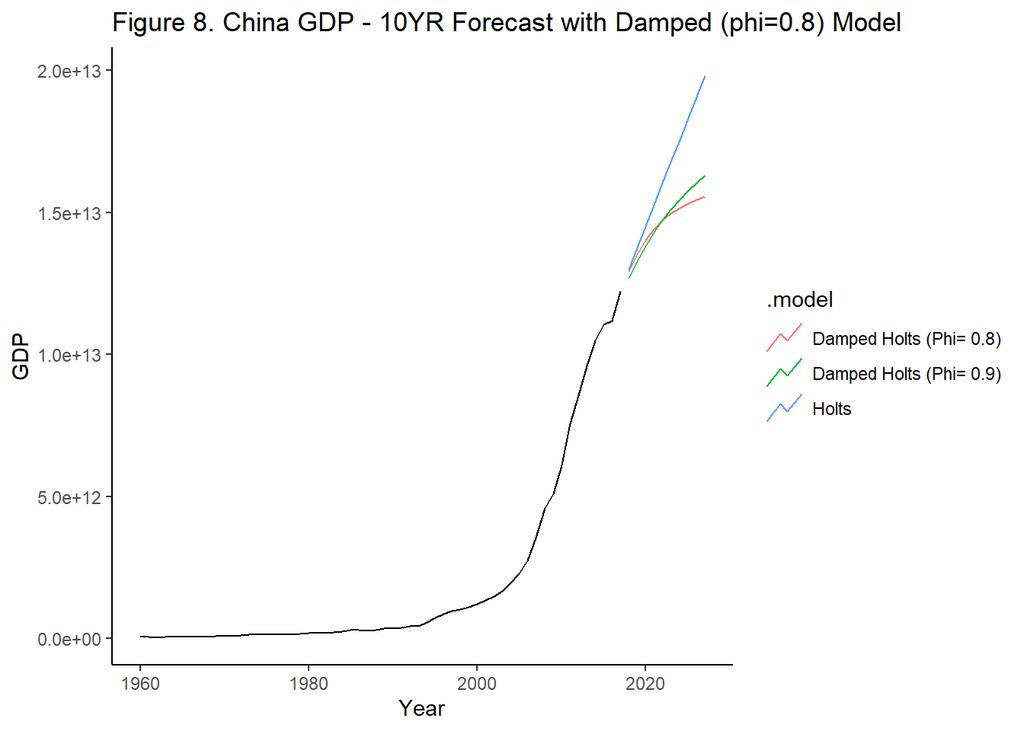

```r
# forecast with damped trend

gdp%>%
  model('Holts'=ETS(GDP ~ error("A") + trend("A") + season("N")),
        'Damped Holts (Phi= 0.9)'= ETS(GDP ~ error("A") + trend("Ad", phi = 0.9) + season("N")),
        'Damped Holts (Phi= 0.8)'= ETS(GDP ~ error("A") + trend("Ad", phi = 0.8) + season("N")))%>%
  forecast(h=10)%>%
  autoplot(gdp, color='steelblue', level=NULL) +   # level NULL removes confidence intervals
  labs(title="Figure 8. China GDP - 10YR Forecast with Damped (phi=0.8) Model") +
  #guides(color = guide_legend(title = "Forecast"))+
  theme_classic()
```

# 4 Hyndman: Exercies 8.7

Find an ETS model for the Gas data from aus_production and forecast the next few years.

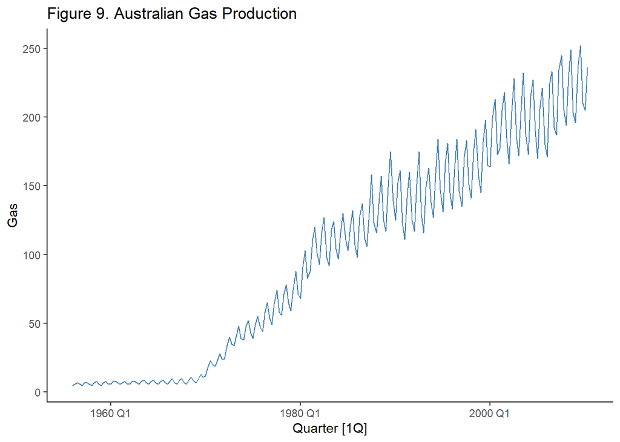

```r
#subset data

gas<-aus_production%>%
  select(Gas)

#Evaluate raw data

gas%>%autoplot(color='steelblue')+
  labs(title='Figure 9. Australian Gas Production')+
  theme_classic()
```

[figure not shown]

```r
#plot forecast with seasonality

gas%>%
  model(
        'Holts'=ETS(Gas ~ error("M") + trend("A") + season("M")),
        'Damped Holts (Phi= 0.8)'= ETS(Gas ~ error("M") + trend("Ad", phi = 0.8) + season("M")))%>%
  forecast(h=20)%>%
  autoplot(gas, color='steelblue', level=NULL) +   # level NULL removes confidence intervals
  labs(title="Figure 9. Australian Gas Production', subtitle = '5YR Multiplicative Forecast with Damped Model (phi=0.8), ETS(M,A,M)") +
  #guides(color = guide_legend(title = "Forecast"))+
  theme_classic()
```

Why is multiplicative seasonality necessary here? Experiment with making the trend damped.

*A multiplicative seasonal model is necessary due to the fact that there is an obvious seasonal signal that is also increasing over time(annual).*

Does it improve the forecasts?

*The multiplicative model generates a forecast that captures the increase in seasonality over time. It also has a lower RMSE (4.59) that the additive model (4.76).*

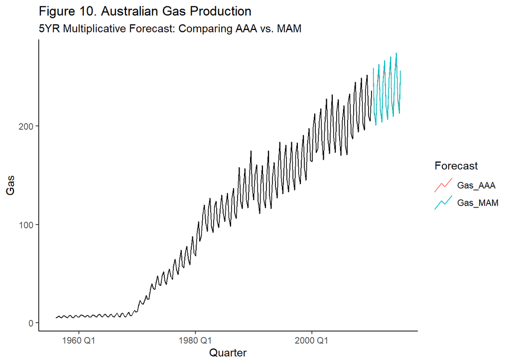

```r
gas_mod<-gas%>%
  model(
        Gas_AAA=ETS(Gas ~ error("A") + trend("A") + season("A")),
        Gas_MAM = ETS(Gas ~ error("M") + trend("A") + season("M")))

gas_fc<-gas_mod%>%
  forecast(h=20)

gas_fc%>%
  autoplot(gas, level=NULL) +   # level NULL removes confidence intervals
  labs(title='Figure 10. Australian Gas Production',
       subtitle = '5YR Multiplicative Forecast: Comparing AAA vs. MAM') +
  guides(color = guide_legend(title = "Forecast"))+
  theme_classic()
```

```r
# assess rmse

gas_mod %>% accuracy()%>%
  select(.model, RMSE)%>%
  rename(Model = '.model')%>%flextable()
```

| Model | RMSE |
| --- | --- |
| Gas_AAA | 4.763979 |
| Gas_MAM | 4.595113 |